# Risk Factor Analysis

## Outcome Variable

**Outcome Variable:** ever_wasted

## Predictor Variables

**Intervention Variable:** impsan

**Adjustment Set:**

- arm
- sex
- W_mage
- meducyrs
- feducyrs
- hhwealth_quart
- hfoodsec
- W_mhtcm
- W_nrooms
- W_nchldlt5
- W_parity
- impfloor
- safeh20
- delta_W_mage
- delta_meducyrs
- delta_feducyrs
- delta_hhwealth_quart
- delta_hfoodsec
- delta_W_mhtcm
- delta_W_nrooms
- delta_W_nchldlt5
- delta_W_parity
- delta_impfloor
- delta_safeh20

## Stratifying Variables

The analysis was stratified on these variable(s):

- agecat
- studyid
- country

## Data Summary

| agecat | studyid | country | impsan | ever_wasted | n_cell | n |
| --- | --- | --- | --- | --- | --- | --- |
| 0-24 months (no birth wast) | ki0047075b-MAL-ED | BANGLADESH | 1 | 0 | 157 | 242 |
| 0-24 months (no birth wast) | ki0047075b-MAL-ED | BANGLADESH | 1 | 1 | 47 | 242 |
| 0-24 months (no birth wast) | ki0047075b-MAL-ED | BANGLADESH | 0 | 0 | 28 | 242 |
| 0-24 months (no birth wast) | ki0047075b-MAL-ED | BANGLADESH | 0 | 1 | 10 | 242 |
| 0-24 months (no birth wast) | ki0047075b-MAL-ED | BRAZIL | 1 | 0 | 193 | 209 |
| 0-24 months (no birth wast) | ki0047075b-MAL-ED | BRAZIL | 1 | 1 | 12 | 209 |
| 0-24 months (no birth wast) | ki0047075b-MAL-ED | BRAZIL | 0 | 0 | 4 | 209 |
| 0-24 months (no birth wast) | ki0047075b-MAL-ED | BRAZIL | 0 | 1 | 0 | 209 |
| 0-24 months (no birth wast) | ki0047075b-MAL-ED | INDIA | 1 | 0 | 75 | 229 |
| 0-24 months (no birth wast) | ki0047075b-MAL-ED | INDIA | 1 | 1 | 30 | 229 |
| 0-24 months (no birth wast) | ki0047075b-MAL-ED | INDIA | 0 | 0 | 69 | 229 |
| 0-24 months (no birth wast) | ki0047075b-MAL-ED | INDIA | 0 | 1 | 55 | 229 |
| 0-24 months (no birth wast) | ki0047075b-MAL-ED | NEPAL | 1 | 0 | 190 | 236 |
| 0-24 months (no birth wast) | ki0047075b-MAL-ED | NEPAL | 1 | 1 | 45 | 236 |
| 0-24 months (no birth wast) | ki0047075b-MAL-ED | NEPAL | 0 | 0 | 1 | 236 |
| 0-24 months (no birth wast) | ki0047075b-MAL-ED | NEPAL | 0 | 1 | 0 | 236 |
| 0-24 months (no birth wast) | ki0047075b-MAL-ED | PERU | 1 | 0 | 59 | 263 |
| 0-24 months (no birth wast) | ki0047075b-MAL-ED | PERU | 1 | 1 | 6 | 263 |
| 0-24 months (no birth wast) | ki0047075b-MAL-ED | PERU | 0 | 0 | 184 | 263 |
| 0-24 months (no birth wast) | ki0047075b-MAL-ED | PERU | 0 | 1 | 14 | 263 |
| 0-24 months (no birth wast) | ki0047075b-MAL-ED | SOUTH AFRICA | 1 | 0 | 3 | 250 |
| 0-24 months (no birth wast) | ki0047075b-MAL-ED | SOUTH AFRICA | 1 | 1 | 1 | 250 |
| 0-24 months (no birth wast) | ki0047075b-MAL-ED | SOUTH AFRICA | 0 | 0 | 204 | 250 |
| 0-24 months (no birth wast) | ki0047075b-MAL-ED | SOUTH AFRICA | 0 | 1 | 42 | 250 |
| 0-24 months (no birth wast) | ki0047075b-MAL-ED | TANZANIA, UNITED REPUBLIC OF | 1 | 0 | 0 | 241 |
| 0-24 months (no birth wast) | ki0047075b-MAL-ED | TANZANIA, UNITED REPUBLIC OF | 1 | 1 | 0 | 241 |
| 0-24 months (no birth wast) | ki0047075b-MAL-ED | TANZANIA, UNITED REPUBLIC OF | 0 | 0 | 212 | 241 |
| 0-24 months (no birth wast) | ki0047075b-MAL-ED | TANZANIA, UNITED REPUBLIC OF | 0 | 1 | 29 | 241 |
| 0-24 months (no birth wast) | ki1017093-NIH-Birth | BANGLADESH | 1 | 0 | 180 | 602 |
| 0-24 months (no birth wast) | ki1017093-NIH-Birth | BANGLADESH | 1 | 1 | 53 | 602 |

[output cut: 174 more lines]

The following strata were considered:

- agecat: 0-24 months (no birth wast), studyid: ki0047075b-MAL-ED, country: BANGLADESH
- agecat: 0-24 months (no birth wast), studyid: ki0047075b-MAL-ED, country: BRAZIL
- agecat: 0-24 months (no birth wast), studyid: ki0047075b-MAL-ED, country: INDIA
- agecat: 0-24 months (no birth wast), studyid: ki0047075b-MAL-ED, country: NEPAL
- agecat: 0-24 months (no birth wast), studyid: ki0047075b-MAL-ED, country: PERU
- agecat: 0-24 months (no birth wast), studyid: ki0047075b-MAL-ED, country: SOUTH AFRICA
- agecat: 0-24 months (no birth wast), studyid: ki0047075b-MAL-ED, country: TANZANIA, UNITED REPUBLIC OF
- agecat: 0-24 months (no birth wast), studyid: ki1017093-NIH-Birth, country: BANGLADESH
- agecat: 0-24 months (no birth wast), studyid: ki1017093b-PROVIDE, country: BANGLADESH
- agecat: 0-24 months (no birth wast), studyid: ki1017093c-NIH-Crypto, country: BANGLADESH
- agecat: 0-24 months (no birth wast), studyid: ki1114097-CONTENT, country: PERU
- agecat: 0-24 months (no birth wast), studyid: ki1135781-COHORTS, country: GUATEMALA
- agecat: 0-24 months (no birth wast), studyid: ki1135781-COHORTS, country: INDIA
- agecat: 0-24 months (no birth wast), studyid: ki1135781-COHORTS, country: PHILIPPINES
- agecat: 0-24 months (no birth wast), studyid: ki1148112-LCNI-5, country: MALAWI
- agecat: 0-24 months (no birth wast), studyid: kiGH5241-JiVitA-3, country: BANGLADESH
- agecat: 0-24 months (no birth wast), studyid: kiGH5241-JiVitA-4, country: BANGLADESH
- agecat: 0-6 months (no birth wast), studyid: ki0047075b-MAL-ED, country: BANGLADESH
- agecat: 0-6 months (no birth wast), studyid: ki0047075b-MAL-ED, country: BRAZIL
- agecat: 0-6 months (no birth wast), studyid: ki0047075b-MAL-ED, country: INDIA
- agecat: 0-6 months (no birth wast), studyid: ki0047075b-MAL-ED, country: NEPAL
- agecat: 0-6 months (no birth wast), studyid: ki0047075b-MAL-ED, country: PERU
- agecat: 0-6 months (no birth wast), studyid: ki0047075b-MAL-ED, country: SOUTH AFRICA
- agecat: 0-6 months (no birth wast), studyid: ki0047075b-MAL-ED, country: TANZANIA, UNITED REPUBLIC OF
- agecat: 0-6 months (no birth wast), studyid: ki1017093-NIH-Birth, country: BANGLADESH
- agecat: 0-6 months (no birth wast), studyid: ki1017093b-PROVIDE, country: BANGLADESH
- agecat: 0-6 months (no birth wast), studyid: ki1017093c-NIH-Crypto, country: BANGLADESH
- agecat: 0-6 months (no birth wast), studyid: ki1114097-CONTENT, country: PERU
- agecat: 0-6 months (no birth wast), studyid: ki1135781-COHORTS, country: GUATEMALA
- agecat: 0-6 months (no birth wast), studyid: ki1135781-COHORTS, country: INDIA
- agecat: 0-6 months (no birth wast), studyid: ki1135781-COHORTS, country: PHILIPPINES
- agecat: 0-6 months (no birth wast), studyid: ki1148112-LCNI-5, country: MALAWI
- agecat: 0-6 months (no birth wast), studyid: kiGH5241-JiVitA-3, country: BANGLADESH
- agecat: 0-6 months (no birth wast), studyid: kiGH5241-JiVitA-4, country: BANGLADESH
- agecat: 6-24 months, studyid: ki0047075b-MAL-ED, country: BANGLADESH
- agecat: 6-24 months, studyid: ki0047075b-MAL-ED, country: BRAZIL
- agecat: 6-24 months, studyid: ki0047075b-MAL-ED, country: INDIA
- agecat: 6-24 months, studyid: ki0047075b-MAL-ED, country: NEPAL
- agecat: 6-24 months, studyid: ki0047075b-MAL-ED, country: PERU
- agecat: 6-24 months, studyid: ki0047075b-MAL-ED, country: SOUTH AFRICA
- agecat: 6-24 months, studyid: ki0047075b-MAL-ED, country: TANZANIA, UNITED REPUBLIC OF
- agecat: 6-24 months, studyid: ki1017093-NIH-Birth, country: BANGLADESH
- agecat: 6-24 months, studyid: ki1017093b-PROVIDE, country: BANGLADESH
- agecat: 6-24 months, studyid: ki1017093c-NIH-Crypto, country: BANGLADESH
- agecat: 6-24 months, studyid: ki1114097-CONTENT, country: PERU
- agecat: 6-24 months, studyid: ki1135781-COHORTS, country: GUATEMALA
- agecat: 6-24 months, studyid: ki1135781-COHORTS, country: INDIA
- agecat: 6-24 months, studyid: ki1135781-COHORTS, country: PHILIPPINES
- agecat: 6-24 months, studyid: ki1148112-LCNI-5, country: MALAWI
- agecat: 6-24 months, studyid: kiGH5241-JiVitA-3, country: BANGLADESH
- agecat: 6-24 months, studyid: kiGH5241-JiVitA-4, country: BANGLADESH

### Dropped Strata

Some strata were dropped due to rare outcomes:

- agecat: 0-24 months (no birth wast), studyid: ki0047075b-MAL-ED, country: BRAZIL
- agecat: 0-24 months (no birth wast), studyid: ki0047075b-MAL-ED, country: NEPAL
- agecat: 0-24 months (no birth wast), studyid: ki0047075b-MAL-ED, country: SOUTH AFRICA
- agecat: 0-24 months (no birth wast), studyid: ki0047075b-MAL-ED, country: TANZANIA, UNITED REPUBLIC OF
- agecat: 0-24 months (no birth wast), studyid: ki1114097-CONTENT, country: PERU
- agecat: 0-24 months (no birth wast), studyid: ki1148112-LCNI-5, country: MALAWI
- agecat: 0-6 months (no birth wast), studyid: ki0047075b-MAL-ED, country: BANGLADESH
- agecat: 0-6 months (no birth wast), studyid: ki0047075b-MAL-ED, country: BRAZIL
- agecat: 0-6 months (no birth wast), studyid: ki0047075b-MAL-ED, country: NEPAL
- agecat: 0-6 months (no birth wast), studyid: ki0047075b-MAL-ED, country: PERU
- agecat: 0-6 months (no birth wast), studyid: ki0047075b-MAL-ED, country: SOUTH AFRICA
- agecat: 0-6 months (no birth wast), studyid: ki0047075b-MAL-ED, country: TANZANIA, UNITED REPUBLIC OF
- agecat: 0-6 months (no birth wast), studyid: ki1017093b-PROVIDE, country: BANGLADESH
- agecat: 0-6 months (no birth wast), studyid: ki1017093c-NIH-Crypto, country: BANGLADESH
- agecat: 0-6 months (no birth wast), studyid: ki1114097-CONTENT, country: PERU
- agecat: 0-6 months (no birth wast), studyid: ki1135781-COHORTS, country: GUATEMALA
- agecat: 0-6 months (no birth wast), studyid: ki1148112-LCNI-5, country: MALAWI
- agecat: 6-24 months, studyid: ki0047075b-MAL-ED, country: BRAZIL
- agecat: 6-24 months, studyid: ki0047075b-MAL-ED, country: NEPAL
- agecat: 6-24 months, studyid: ki0047075b-MAL-ED, country: SOUTH AFRICA
- agecat: 6-24 months, studyid: ki0047075b-MAL-ED, country: TANZANIA, UNITED REPUBLIC OF
- agecat: 6-24 months, studyid: ki1114097-CONTENT, country: PERU
- agecat: 6-24 months, studyid: ki1148112-LCNI-5, country: MALAWI

## Methods Detail

We’re interested in the causal parameters $E[Y_a]$ for all values of $a \in \mathcal{A}$. These parameters represent the mean outcome if, possibly contrary to fact, we intervened to set all units to have $A=a$. Under the randomization and positivity assumptions, these are identified by the statistical parameters $\psi_a=E_W[E_{Y|A,W}(Y|A=a,W)]$. In addition, we’re interested in the mean of $Y$, $E[Y]$ under no intervention (the observed mean). We will estimate these parameters by using SuperLearner to fit the relevant likelihood factors – $E_{Y|A,W}(Y|A=a,W)$ and $p(A=a|W)$, and then updating our likelihood fit using a joint TMLE.

For unadjusted analyses ($W=\{\}$), initial likelihoods were estimated using Lrnr_glm to estimate the simple $E(Y|A)$ and Lrnr_mean to estimate $p(A)$. For adjusted analyses, a small library containing Lrnr_glmnet, Lrnr_xgboost, and Lrnr_mean was used.

Having estimated these parameters, we will then use the delta method to estimate relative risks and attributable risks relative to a prespecified baseline level of $A$.

# Results Detail

## Results Plots

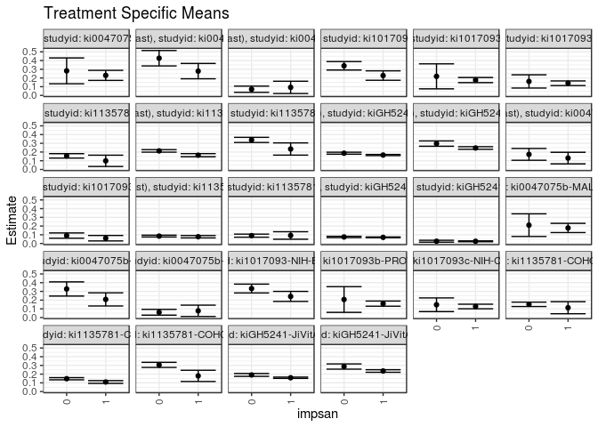

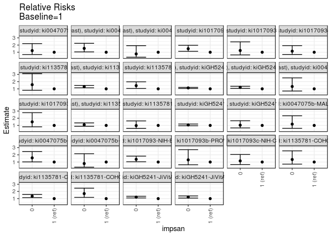

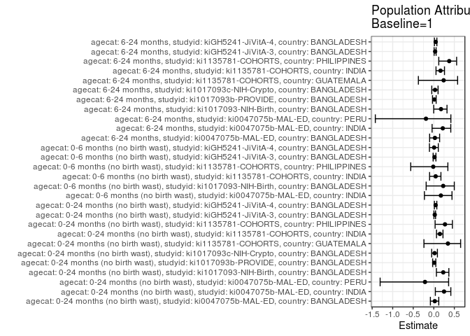

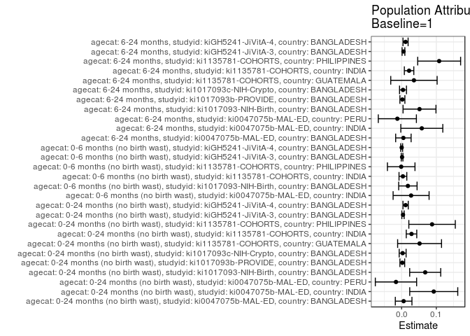

## Results Table

### Parameter: TSM

| agecat | studyid | country | intervention_level | baseline_level | estimate | ci_lower | ci_upper |
| --- | --- | --- | --- | --- | --- | --- | --- |
| 0-24 months (no birth wast) | ki0047075b-MAL-ED | BANGLADESH | 1 | NA | 0.2297256 | 0.1721185 | 0.2873327 |
| 0-24 months (no birth wast) | ki0047075b-MAL-ED | BANGLADESH | 0 | NA | 0.2816389 | 0.1333876 | 0.4298901 |
| 0-24 months (no birth wast) | ki0047075b-MAL-ED | INDIA | 1 | NA | 0.2785425 | 0.1905008 | 0.3665841 |
| 0-24 months (no birth wast) | ki0047075b-MAL-ED | INDIA | 0 | NA | 0.4269417 | 0.3385875 | 0.5152959 |
| 0-24 months (no birth wast) | ki0047075b-MAL-ED | PERU | 1 | NA | 0.0923077 | 0.0218048 | 0.1628106 |
| 0-24 months (no birth wast) | ki0047075b-MAL-ED | PERU | 0 | NA | 0.0707071 | 0.0349345 | 0.1064797 |
| 0-24 months (no birth wast) | ki1017093-NIH-Birth | BANGLADESH | 1 | NA | 0.2276862 | 0.1736615 | 0.2817108 |
| 0-24 months (no birth wast) | ki1017093-NIH-Birth | BANGLADESH | 0 | NA | 0.3394426 | 0.2910487 | 0.3878364 |
| 0-24 months (no birth wast) | ki1017093b-PROVIDE | BANGLADESH | 1 | NA | 0.1761103 | 0.1468731 | 0.2053474 |
| 0-24 months (no birth wast) | ki1017093b-PROVIDE | BANGLADESH | 0 | NA | 0.2187500 | 0.0754126 | 0.3620874 |
| 0-24 months (no birth wast) | ki1017093c-NIH-Crypto | BANGLADESH | 1 | NA | 0.1397005 | 0.1130388 | 0.1663623 |
| 0-24 months (no birth wast) | ki1017093c-NIH-Crypto | BANGLADESH | 0 | NA | 0.1605351 | 0.0844276 | 0.2366427 |
| 0-24 months (no birth wast) | ki1135781-COHORTS | GUATEMALA | 1 | NA | 0.0987654 | 0.0337559 | 0.1637749 |
| 0-24 months (no birth wast) | ki1135781-COHORTS | GUATEMALA | 0 | NA | 0.1558935 | 0.1305672 | 0.1812199 |
| 0-24 months (no birth wast) | ki1135781-COHORTS | INDIA | 1 | NA | 0.1636142 | 0.1458436 | 0.1813848 |
| 0-24 months (no birth wast) | ki1135781-COHORTS | INDIA | 0 | NA | 0.2127960 | 0.1983480 | 0.2272440 |
| 0-24 months (no birth wast) | ki1135781-COHORTS | PHILIPPINES | 1 | NA | 0.2345626 | 0.1643154 | 0.3048099 |
| 0-24 months (no birth wast) | ki1135781-COHORTS | PHILIPPINES | 0 | NA | 0.3390124 | 0.3095931 | 0.3684317 |
| 0-24 months (no birth wast) | kiGH5241-JiVitA-3 | BANGLADESH | 1 | NA | 0.1652609 | 0.1589698 | 0.1715519 |
| 0-24 months (no birth wast) | kiGH5241-JiVitA-3 | BANGLADESH | 0 | NA | 0.1864029 | 0.1749423 | 0.1978635 |
| 0-24 months (no birth wast) | kiGH5241-JiVitA-4 | BANGLADESH | 1 | NA | 0.2462612 | 0.2313054 | 0.2612170 |
| 0-24 months (no birth wast) | kiGH5241-JiVitA-4 | BANGLADESH | 0 | NA | 0.2967099 | 0.2663380 | 0.3270818 |
| 0-6 months (no birth wast) | ki0047075b-MAL-ED | INDIA | 1 | NA | 0.1305550 | 0.0642091 | 0.1969009 |
| 0-6 months (no birth wast) | ki0047075b-MAL-ED | INDIA | 0 | NA | 0.1728763 | 0.1050724 | 0.2406803 |
| 0-6 months (no birth wast) | ki1017093-NIH-Birth | BANGLADESH | 1 | NA | 0.0607100 | 0.0292915 | 0.0921284 |
| 0-6 months (no birth wast) | ki1017093-NIH-Birth | BANGLADESH | 0 | NA | 0.0907679 | 0.0606083 | 0.1209275 |
| 0-6 months (no birth wast) | ki1135781-COHORTS | INDIA | 1 | NA | 0.0777931 | 0.0643205 | 0.0912657 |
| 0-6 months (no birth wast) | ki1135781-COHORTS | INDIA | 0 | NA | 0.0849776 | 0.0746944 | 0.0952608 |
| 0-6 months (no birth wast) | ki1135781-COHORTS | PHILIPPINES | 1 | NA | 0.0918523 | 0.0488673 | 0.1348372 |
| 0-6 months (no birth wast) | ki1135781-COHORTS | PHILIPPINES | 0 | NA | 0.0899992 | 0.0722036 | 0.1077948 |
| 0-6 months (no birth wast) | kiGH5241-JiVitA-3 | BANGLADESH | 1 | NA | 0.0703218 | 0.0659850 | 0.0746585 |
| 0-6 months (no birth wast) | kiGH5241-JiVitA-3 | BANGLADESH | 0 | NA | 0.0749188 | 0.0676195 | 0.0822181 |
| 0-6 months (no birth wast) | kiGH5241-JiVitA-4 | BANGLADESH | 1 | NA | 0.0250795 | 0.0198564 | 0.0303026 |
| 0-6 months (no birth wast) | kiGH5241-JiVitA-4 | BANGLADESH | 0 | NA | 0.0259889 | 0.0151810 | 0.0367969 |
| 6-24 months | ki0047075b-MAL-ED | BANGLADESH | 1 | NA | 0.1782178 | 0.1253328 | 0.2311029 |
| 6-24 months | ki0047075b-MAL-ED | BANGLADESH | 0 | NA | 0.2105263 | 0.0806335 | 0.3404191 |
| 6-24 months | ki0047075b-MAL-ED | INDIA | 1 | NA | 0.2079278 | 0.1323959 | 0.2834598 |
| 6-24 months | ki0047075b-MAL-ED | INDIA | 0 | NA | 0.3278257 | 0.2465695 | 0.4090819 |
| 6-24 months | ki0047075b-MAL-ED | PERU | 1 | NA | 0.0769231 | 0.0120199 | 0.1418262 |
| 6-24 months | ki0047075b-MAL-ED | PERU | 0 | NA | 0.0606061 | 0.0273076 | 0.0939046 |
| 6-24 months | ki1017093-NIH-Birth | BANGLADESH | 1 | NA | 0.2423041 | 0.1846785 | 0.2999297 |
| 6-24 months | ki1017093-NIH-Birth | BANGLADESH | 0 | NA | 0.3328338 | 0.2823576 | 0.3833101 |
| 6-24 months | ki1017093b-PROVIDE | BANGLADESH | 1 | NA | 0.1592466 | 0.1295460 | 0.1889472 |
| 6-24 months | ki1017093b-PROVIDE | BANGLADESH | 0 | NA | 0.2068966 | 0.0593445 | 0.3544486 |
| 6-24 months | ki1017093c-NIH-Crypto | BANGLADESH | 1 | NA | 0.1267163 | 0.1006648 | 0.1527679 |
| 6-24 months | ki1017093c-NIH-Crypto | BANGLADESH | 0 | NA | 0.1465269 | 0.0682378 | 0.2248161 |
| 6-24 months | ki1135781-COHORTS | GUATEMALA | 1 | NA | 0.1125000 | 0.0432186 | 0.1817814 |
| 6-24 months | ki1135781-COHORTS | GUATEMALA | 0 | NA | 0.1516710 | 0.1264510 | 0.1768909 |
| 6-24 months | ki1135781-COHORTS | INDIA | 1 | NA | 0.1100265 | 0.0943473 | 0.1257057 |
| 6-24 months | ki1135781-COHORTS | INDIA | 0 | NA | 0.1474588 | 0.1348987 | 0.1600190 |
| 6-24 months | ki1135781-COHORTS | PHILIPPINES | 1 | NA | 0.1801791 | 0.1159743 | 0.2443840 |
| 6-24 months | ki1135781-COHORTS | PHILIPPINES | 0 | NA | 0.3060086 | 0.2768507 | 0.3351665 |
| 6-24 months | kiGH5241-JiVitA-3 | BANGLADESH | 1 | NA | 0.1584653 | 0.1511425 | 0.1657880 |
| 6-24 months | kiGH5241-JiVitA-3 | BANGLADESH | 0 | NA | 0.1909329 | 0.1746267 | 0.2072391 |
| 6-24 months | kiGH5241-JiVitA-4 | BANGLADESH | 1 | NA | 0.2359517 | 0.2210902 | 0.2508133 |
| 6-24 months | kiGH5241-JiVitA-4 | BANGLADESH | 0 | NA | 0.2872007 | 0.2573555 | 0.3170459 |

### Parameter: E(Y)

| agecat | studyid | country | intervention_level | baseline_level | estimate | ci_lower | ci_upper |
| --- | --- | --- | --- | --- | --- | --- | --- |
| 0-24 months (no birth wast) | ki0047075b-MAL-ED | BANGLADESH | NA | NA | 0.2355372 | 0.1819640 | 0.2891104 |
| 0-24 months (no birth wast) | ki0047075b-MAL-ED | INDIA | NA | NA | 0.3711790 | 0.3084692 | 0.4338889 |
| 0-24 months (no birth wast) | ki0047075b-MAL-ED | PERU | NA | NA | 0.0760456 | 0.0439490 | 0.1081423 |
| 0-24 months (no birth wast) | ki1017093-NIH-Birth | BANGLADESH | NA | NA | 0.2956811 | 0.2591967 | 0.3321655 |
| 0-24 months (no birth wast) | ki1017093b-PROVIDE | BANGLADESH | NA | NA | 0.1781022 | 0.1494298 | 0.2067746 |
| 0-24 months (no birth wast) | ki1017093c-NIH-Crypto | BANGLADESH | NA | NA | 0.1426649 | 0.1175009 | 0.1678289 |
| 0-24 months (no birth wast) | ki1135781-COHORTS | GUATEMALA | NA | NA | 0.1505747 | 0.1267966 | 0.1743528 |
| 0-24 months (no birth wast) | ki1135781-COHORTS | INDIA | NA | NA | 0.1921440 | 0.1814014 | 0.2028866 |
| 0-24 months (no birth wast) | ki1135781-COHORTS | PHILIPPINES | NA | NA | 0.3223629 | 0.2957407 | 0.3489850 |
| 0-24 months (no birth wast) | kiGH5241-JiVitA-3 | BANGLADESH | NA | NA | 0.1692824 | 0.1639784 | 0.1745865 |
| 0-24 months (no birth wast) | kiGH5241-JiVitA-4 | BANGLADESH | NA | NA | 0.2577588 | 0.2441239 | 0.2713937 |
| 0-6 months (no birth wast) | ki0047075b-MAL-ED | INDIA | NA | NA | 0.1578947 | 0.1104594 | 0.2053301 |
| 0-6 months (no birth wast) | ki1017093-NIH-Birth | BANGLADESH | NA | NA | 0.0787671 | 0.0569010 | 0.1006332 |
| 0-6 months (no birth wast) | ki1135781-COHORTS | INDIA | NA | NA | 0.0815160 | 0.0737115 | 0.0893204 |
| 0-6 months (no birth wast) | ki1135781-COHORTS | PHILIPPINES | NA | NA | 0.0906780 | 0.0742871 | 0.1070688 |
| 0-6 months (no birth wast) | kiGH5241-JiVitA-3 | BANGLADESH | NA | NA | 0.0716493 | 0.0679955 | 0.0753031 |
| 0-6 months (no birth wast) | kiGH5241-JiVitA-4 | BANGLADESH | NA | NA | 0.0252781 | 0.0205710 | 0.0299851 |
| 6-24 months | ki0047075b-MAL-ED | BANGLADESH | NA | NA | 0.1833333 | 0.1342773 | 0.2323893 |
| 6-24 months | ki0047075b-MAL-ED | INDIA | NA | NA | 0.2660944 | 0.2092298 | 0.3229590 |
| 6-24 months | ki0047075b-MAL-ED | PERU | NA | NA | 0.0646388 | 0.0348650 | 0.0944125 |
| 6-24 months | ki1017093-NIH-Birth | BANGLADESH | NA | NA | 0.2939002 | 0.2554778 | 0.3323226 |
| 6-24 months | ki1017093b-PROVIDE | BANGLADESH | NA | NA | 0.1615008 | 0.1323459 | 0.1906557 |
| 6-24 months | ki1017093c-NIH-Crypto | BANGLADESH | NA | NA | 0.1307371 | 0.1060790 | 0.1553953 |
| 6-24 months | ki1135781-COHORTS | GUATEMALA | NA | NA | 0.1480186 | 0.1242431 | 0.1717942 |
| 6-24 months | ki1135781-COHORTS | INDIA | NA | NA | 0.1315423 | 0.1221962 | 0.1408884 |
| 6-24 months | ki1135781-COHORTS | PHILIPPINES | NA | NA | 0.2884097 | 0.2617831 | 0.3150363 |
| 6-24 months | kiGH5241-JiVitA-3 | BANGLADESH | NA | NA | 0.1638320 | 0.1577097 | 0.1699543 |
| 6-24 months | kiGH5241-JiVitA-4 | BANGLADESH | NA | NA | 0.2472801 | 0.2337480 | 0.2608122 |

### Parameter: RR

| agecat | studyid | country | intervention_level | baseline_level | estimate | ci_lower | ci_upper |
| --- | --- | --- | --- | --- | --- | --- | --- |
| 0-24 months (no birth wast) | ki0047075b-MAL-ED | BANGLADESH | 1 | 1 | 1.0000000 | 1.0000000 | 1.000000 |
| 0-24 months (no birth wast) | ki0047075b-MAL-ED | BANGLADESH | 0 | 1 | 1.2259796 | 0.6831688 | 2.200080 |
| 0-24 months (no birth wast) | ki0047075b-MAL-ED | INDIA | 1 | 1 | 1.0000000 | 1.0000000 | 1.000000 |
| 0-24 months (no birth wast) | ki0047075b-MAL-ED | INDIA | 0 | 1 | 1.5327705 | 1.0496126 | 2.238336 |
| 0-24 months (no birth wast) | ki0047075b-MAL-ED | PERU | 1 | 1 | 1.0000000 | 1.0000000 | 1.000000 |
| 0-24 months (no birth wast) | ki0047075b-MAL-ED | PERU | 0 | 1 | 0.7659933 | 0.3064416 | 1.914706 |
| 0-24 months (no birth wast) | ki1017093-NIH-Birth | BANGLADESH | 1 | 1 | 1.0000000 | 1.0000000 | 1.000000 |
| 0-24 months (no birth wast) | ki1017093-NIH-Birth | BANGLADESH | 0 | 1 | 1.4908351 | 1.1302835 | 1.966400 |
| 0-24 months (no birth wast) | ki1017093b-PROVIDE | BANGLADESH | 1 | 1 | 1.0000000 | 1.0000000 | 1.000000 |
| 0-24 months (no birth wast) | ki1017093b-PROVIDE | BANGLADESH | 0 | 1 | 1.2421196 | 0.6318260 | 2.441908 |
| 0-24 months (no birth wast) | ki1017093c-NIH-Crypto | BANGLADESH | 1 | 1 | 1.0000000 | 1.0000000 | 1.000000 |
| 0-24 months (no birth wast) | ki1017093c-NIH-Crypto | BANGLADESH | 0 | 1 | 1.1491376 | 0.6891951 | 1.916028 |
| 0-24 months (no birth wast) | ki1135781-COHORTS | GUATEMALA | 1 | 1 | 1.0000000 | 1.0000000 | 1.000000 |
| 0-24 months (no birth wast) | ki1135781-COHORTS | GUATEMALA | 0 | 1 | 1.5784220 | 0.8012777 | 3.109304 |
| 0-24 months (no birth wast) | ki1135781-COHORTS | INDIA | 1 | 1 | 1.0000000 | 1.0000000 | 1.000000 |
| 0-24 months (no birth wast) | ki1135781-COHORTS | INDIA | 0 | 1 | 1.3005962 | 1.1447351 | 1.477678 |
| 0-24 months (no birth wast) | ki1135781-COHORTS | PHILIPPINES | 1 | 1 | 1.0000000 | 1.0000000 | 1.000000 |
| 0-24 months (no birth wast) | ki1135781-COHORTS | PHILIPPINES | 0 | 1 | 1.4452959 | 1.0581330 | 1.974119 |
| 0-24 months (no birth wast) | kiGH5241-JiVitA-3 | BANGLADESH | 1 | 1 | 1.0000000 | 1.0000000 | 1.000000 |
| 0-24 months (no birth wast) | kiGH5241-JiVitA-3 | BANGLADESH | 0 | 1 | 1.1279314 | 1.0524613 | 1.208813 |
| 0-24 months (no birth wast) | kiGH5241-JiVitA-4 | BANGLADESH | 1 | 1 | 1.0000000 | 1.0000000 | 1.000000 |
| 0-24 months (no birth wast) | kiGH5241-JiVitA-4 | BANGLADESH | 0 | 1 | 1.2048586 | 1.0701312 | 1.356548 |
| 0-6 months (no birth wast) | ki0047075b-MAL-ED | INDIA | 1 | 1 | 1.0000000 | 1.0000000 | 1.000000 |
| 0-6 months (no birth wast) | ki0047075b-MAL-ED | INDIA | 0 | 1 | 1.3241649 | 0.6957933 | 2.520020 |
| 0-6 months (no birth wast) | ki1017093-NIH-Birth | BANGLADESH | 1 | 1 | 1.0000000 | 1.0000000 | 1.000000 |
| 0-6 months (no birth wast) | ki1017093-NIH-Birth | BANGLADESH | 0 | 1 | 1.4951067 | 0.8080256 | 2.766427 |
| 0-6 months (no birth wast) | ki1135781-COHORTS | INDIA | 1 | 1 | 1.0000000 | 1.0000000 | 1.000000 |
| 0-6 months (no birth wast) | ki1135781-COHORTS | INDIA | 0 | 1 | 1.0923539 | 0.8843021 | 1.349355 |
| 0-6 months (no birth wast) | ki1135781-COHORTS | PHILIPPINES | 1 | 1 | 1.0000000 | 1.0000000 | 1.000000 |
| 0-6 months (no birth wast) | ki1135781-COHORTS | PHILIPPINES | 0 | 1 | 0.9798257 | 0.5894658 | 1.628692 |
| 0-6 months (no birth wast) | kiGH5241-JiVitA-3 | BANGLADESH | 1 | 1 | 1.0000000 | 1.0000000 | 1.000000 |
| 0-6 months (no birth wast) | kiGH5241-JiVitA-3 | BANGLADESH | 0 | 1 | 1.0653714 | 0.9541494 | 1.189558 |
| 0-6 months (no birth wast) | kiGH5241-JiVitA-4 | BANGLADESH | 1 | 1 | 1.0000000 | 1.0000000 | 1.000000 |
| 0-6 months (no birth wast) | kiGH5241-JiVitA-4 | BANGLADESH | 0 | 1 | 1.0362613 | 0.6501916 | 1.651571 |
| 6-24 months | ki0047075b-MAL-ED | BANGLADESH | 1 | 1 | 1.0000000 | 1.0000000 | 1.000000 |
| 6-24 months | ki0047075b-MAL-ED | BANGLADESH | 0 | 1 | 1.1812865 | 0.5956883 | 2.342564 |
| 6-24 months | ki0047075b-MAL-ED | INDIA | 1 | 1 | 1.0000000 | 1.0000000 | 1.000000 |
| 6-24 months | ki0047075b-MAL-ED | INDIA | 0 | 1 | 1.5766320 | 1.0150756 | 2.448851 |
| 6-24 months | ki0047075b-MAL-ED | PERU | 1 | 1 | 1.0000000 | 1.0000000 | 1.000000 |
| 6-24 months | ki0047075b-MAL-ED | PERU | 0 | 1 | 0.7878788 | 0.2878628 | 2.156419 |
| 6-24 months | ki1017093-NIH-Birth | BANGLADESH | 1 | 1 | 1.0000000 | 1.0000000 | 1.000000 |
| 6-24 months | ki1017093-NIH-Birth | BANGLADESH | 0 | 1 | 1.3736203 | 1.0363391 | 1.820671 |
| 6-24 months | ki1017093b-PROVIDE | BANGLADESH | 1 | 1 | 1.0000000 | 1.0000000 | 1.000000 |
| 6-24 months | ki1017093b-PROVIDE | BANGLADESH | 0 | 1 | 1.2992214 | 0.6216443 | 2.715341 |
| 6-24 months | ki1017093c-NIH-Crypto | BANGLADESH | 1 | 1 | 1.0000000 | 1.0000000 | 1.000000 |
| 6-24 months | ki1017093c-NIH-Crypto | BANGLADESH | 0 | 1 | 1.1563382 | 0.6522125 | 2.050126 |
| 6-24 months | ki1135781-COHORTS | GUATEMALA | 1 | 1 | 1.0000000 | 1.0000000 | 1.000000 |
| 6-24 months | ki1135781-COHORTS | GUATEMALA | 0 | 1 | 1.3481862 | 0.7123909 | 2.551417 |
| 6-24 months | ki1135781-COHORTS | INDIA | 1 | 1 | 1.0000000 | 1.0000000 | 1.000000 |
| 6-24 months | ki1135781-COHORTS | INDIA | 0 | 1 | 1.3402121 | 1.1359885 | 1.581150 |
| 6-24 months | ki1135781-COHORTS | PHILIPPINES | 1 | 1 | 1.0000000 | 1.0000000 | 1.000000 |
| 6-24 months | ki1135781-COHORTS | PHILIPPINES | 0 | 1 | 1.6983575 | 1.1743695 | 2.456142 |
| 6-24 months | kiGH5241-JiVitA-3 | BANGLADESH | 1 | 1 | 1.0000000 | 1.0000000 | 1.000000 |
| 6-24 months | kiGH5241-JiVitA-3 | BANGLADESH | 0 | 1 | 1.2048882 | 1.0958806 | 1.324739 |
| 6-24 months | kiGH5241-JiVitA-4 | BANGLADESH | 1 | 1 | 1.0000000 | 1.0000000 | 1.000000 |
| 6-24 months | kiGH5241-JiVitA-4 | BANGLADESH | 0 | 1 | 1.2172011 | 1.0796912 | 1.372224 |

### Parameter: PAR

| agecat | studyid | country | intervention_level | baseline_level | estimate | ci_lower | ci_upper |
| --- | --- | --- | --- | --- | --- | --- | --- |
| 0-24 months (no birth wast) | ki0047075b-MAL-ED | BANGLADESH | 1 | NA | 0.0058116 | -0.0181463 | 0.0297696 |
| 0-24 months (no birth wast) | ki0047075b-MAL-ED | INDIA | 1 | NA | 0.0926365 | 0.0234159 | 0.1618572 |
| 0-24 months (no birth wast) | ki0047075b-MAL-ED | PERU | 1 | NA | -0.0162621 | -0.0757925 | 0.0432684 |
| 0-24 months (no birth wast) | ki1017093-NIH-Birth | BANGLADESH | 1 | NA | 0.0679949 | 0.0232544 | 0.1127354 |
| 0-24 months (no birth wast) | ki1017093b-PROVIDE | BANGLADESH | 1 | NA | 0.0019919 | -0.0048752 | 0.0088590 |
| 0-24 months (no birth wast) | ki1017093c-NIH-Crypto | BANGLADESH | 1 | NA | 0.0029643 | -0.0069947 | 0.0129234 |
| 0-24 months (no birth wast) | ki1135781-COHORTS | GUATEMALA | 1 | NA | 0.0518093 | -0.0114732 | 0.1150918 |
| 0-24 months (no birth wast) | ki1135781-COHORTS | INDIA | 1 | NA | 0.0285298 | 0.0134073 | 0.0436522 |
| 0-24 months (no birth wast) | ki1135781-COHORTS | PHILIPPINES | 1 | NA | 0.0878002 | 0.0208171 | 0.1547834 |
| 0-24 months (no birth wast) | kiGH5241-JiVitA-3 | BANGLADESH | 1 | NA | 0.0040216 | 0.0007232 | 0.0073199 |
| 0-24 months (no birth wast) | kiGH5241-JiVitA-4 | BANGLADESH | 1 | NA | 0.0114976 | 0.0038933 | 0.0191019 |
| 0-6 months (no birth wast) | ki0047075b-MAL-ED | INDIA | 1 | NA | 0.0273398 | -0.0245200 | 0.0791995 |
| 0-6 months (no birth wast) | ki1017093-NIH-Birth | BANGLADESH | 1 | NA | 0.0180571 | -0.0084497 | 0.0445640 |
| 0-6 months (no birth wast) | ki1135781-COHORTS | INDIA | 1 | NA | 0.0037229 | -0.0074856 | 0.0149313 |
| 0-6 months (no birth wast) | ki1135781-COHORTS | PHILIPPINES | 1 | NA | -0.0011743 | -0.0408904 | 0.0385418 |
| 0-6 months (no birth wast) | kiGH5241-JiVitA-3 | BANGLADESH | 1 | NA | 0.0013275 | -0.0011132 | 0.0037683 |
| 0-6 months (no birth wast) | kiGH5241-JiVitA-4 | BANGLADESH | 1 | NA | 0.0001986 | -0.0025215 | 0.0029186 |
| 6-24 months | ki0047075b-MAL-ED | BANGLADESH | 1 | NA | 0.0051155 | -0.0171404 | 0.0273714 |
| 6-24 months | ki0047075b-MAL-ED | INDIA | 1 | NA | 0.0581666 | -0.0024034 | 0.1187365 |
| 6-24 months | ki0047075b-MAL-ED | PERU | 1 | NA | -0.0122843 | -0.0672089 | 0.0426403 |
| 6-24 months | ki1017093-NIH-Birth | BANGLADESH | 1 | NA | 0.0515961 | 0.0041278 | 0.0990643 |
| 6-24 months | ki1017093b-PROVIDE | BANGLADESH | 1 | NA | 0.0022542 | -0.0049112 | 0.0094197 |
| 6-24 months | ki1017093c-NIH-Crypto | BANGLADESH | 1 | NA | 0.0040208 | -0.0059487 | 0.0139904 |
| 6-24 months | ki1135781-COHORTS | GUATEMALA | 1 | NA | 0.0355186 | -0.0313402 | 0.1023775 |
| 6-24 months | ki1135781-COHORTS | INDIA | 1 | NA | 0.0215158 | 0.0078830 | 0.0351486 |
| 6-24 months | ki1135781-COHORTS | PHILIPPINES | 1 | NA | 0.1082306 | 0.0463469 | 0.1701142 |
| 6-24 months | kiGH5241-JiVitA-3 | BANGLADESH | 1 | NA | 0.0053667 | 0.0013961 | 0.0093374 |
| 6-24 months | kiGH5241-JiVitA-4 | BANGLADESH | 1 | NA | 0.0113284 | 0.0039491 | 0.0187077 |

### Parameter: PAF

| agecat | studyid | country | intervention_level | baseline_level | estimate | ci_lower | ci_upper |
| --- | --- | --- | --- | --- | --- | --- | --- |
| 0-24 months (no birth wast) | ki0047075b-MAL-ED | BANGLADESH | 1 | NA | 0.0246739 | -0.0824028 | 0.1211580 |
| 0-24 months (no birth wast) | ki0047075b-MAL-ED | INDIA | 1 | NA | 0.2495737 | 0.0378136 | 0.4147292 |
| 0-24 months (no birth wast) | ki0047075b-MAL-ED | PERU | 1 | NA | -0.2138462 | -1.3054314 | 0.3608908 |
| 0-24 months (no birth wast) | ki1017093-NIH-Birth | BANGLADESH | 1 | NA | 0.2299602 | 0.0639027 | 0.3665603 |
| 0-24 months (no birth wast) | ki1017093b-PROVIDE | BANGLADESH | 1 | NA | 0.0111842 | -0.0281096 | 0.0489762 |
| 0-24 months (no birth wast) | ki1017093c-NIH-Crypto | BANGLADESH | 1 | NA | 0.0207783 | -0.0515116 | 0.0880984 |
| 0-24 months (no birth wast) | ki1135781-COHORTS | GUATEMALA | 1 | NA | 0.3440769 | -0.2397390 | 0.6529631 |
| 0-24 months (no birth wast) | ki1135781-COHORTS | INDIA | 1 | NA | 0.1484813 | 0.0663389 | 0.2233969 |
| 0-24 months (no birth wast) | ki1135781-COHORTS | PHILIPPINES | 1 | NA | 0.2723646 | 0.0324392 | 0.4527959 |
| 0-24 months (no birth wast) | kiGH5241-JiVitA-3 | BANGLADESH | 1 | NA | 0.0237566 | 0.0040498 | 0.0430735 |
| 0-24 months (no birth wast) | kiGH5241-JiVitA-4 | BANGLADESH | 1 | NA | 0.0446061 | 0.0147826 | 0.0735268 |
| 0-6 months (no birth wast) | ki0047075b-MAL-ED | INDIA | 1 | NA | 0.1731518 | -0.2277609 | 0.4431506 |
| 0-6 months (no birth wast) | ki1017093-NIH-Birth | BANGLADESH | 1 | NA | 0.2292472 | -0.1855439 | 0.4989136 |
| 0-6 months (no birth wast) | ki1135781-COHORTS | INDIA | 1 | NA | 0.0456704 | -0.1021633 | 0.1736751 |
| 0-6 months (no birth wast) | ki1135781-COHORTS | PHILIPPINES | 1 | NA | -0.0129502 | -0.5608988 | 0.3426427 |
| 0-6 months (no birth wast) | kiGH5241-JiVitA-3 | BANGLADESH | 1 | NA | 0.0185284 | -0.0161205 | 0.0519958 |
| 0-6 months (no birth wast) | kiGH5241-JiVitA-4 | BANGLADESH | 1 | NA | 0.0078547 | -0.1056687 | 0.1097221 |
| 6-24 months | ki0047075b-MAL-ED | BANGLADESH | 1 | NA | 0.0279028 | -0.1012521 | 0.1419104 |
| 6-24 months | ki0047075b-MAL-ED | INDIA | 1 | NA | 0.2185938 | -0.0411807 | 0.4135545 |
| 6-24 months | ki0047075b-MAL-ED | PERU | 1 | NA | -0.1900452 | -1.4225929 | 0.4154166 |
| 6-24 months | ki1017093-NIH-Birth | BANGLADESH | 1 | NA | 0.1755564 | -0.0017132 | 0.3214553 |
| 6-24 months | ki1017093b-PROVIDE | BANGLADESH | 1 | NA | 0.0139581 | -0.0313765 | 0.0572999 |
| 6-24 months | ki1017093c-NIH-Crypto | BANGLADESH | 1 | NA | 0.0307549 | -0.0484535 | 0.1039792 |
| 6-24 months | ki1135781-COHORTS | GUATEMALA | 1 | NA | 0.2399606 | -0.3748179 | 0.5798281 |
| 6-24 months | ki1135781-COHORTS | INDIA | 1 | NA | 0.1635657 | 0.0539099 | 0.2605120 |
| 6-24 months | ki1135781-COHORTS | PHILIPPINES | 1 | NA | 0.3752667 | 0.1214759 | 0.5557417 |
| 6-24 months | kiGH5241-JiVitA-3 | BANGLADESH | 1 | NA | 0.0327576 | 0.0081739 | 0.0567320 |
| 6-24 months | kiGH5241-JiVitA-4 | BANGLADESH | 1 | NA | 0.0458119 | 0.0156065 | 0.0750905 |